# Developing Data Project Course Project

A shiny app to build histograms

Eva Yifan Gong

2017/02/21

# Introduction

This is a pitch presentation for Coursera’s Developing Data Product’s course project. In this presentation, I introduce a new app that allows you to interactively build histograms using the `iris` dataset.

The dataset contains four numeric variables: `Petal.Length`, `Petal.Width`, `Sepal.Length`, and `Sepal.Width`. Using this app, you can create histograms for any above variables. Furthermore, you can change the number of bins and the color of the plot to customize it.

Following slides contain information on:

- Code to build this app
- Sample plots
- Link to the app and the source code

# What is this app about?

- Using the `iris` dataset, this app allows you to create histograms for any variable, with any number of bins.
- You can also select the color from the side bar to make it prettier.
- A glimpse of the code

```r
output$distPlot <- renderPlot({
      # generate bins based on input$bins from ui.R
     chosen <- input$var
     if (chosen=="Petal.Length"){
       x  <- iris$Petal.Length
     } else if (chosen=="Petal.Width"){
       x  <- iris$Petal.Width
     } ### ... more conditional statements
     color=input$col
      bins <- seq(min(x), max(x), length.out = input$bins + 1)
      # draw the histogram with the specified number of bins
      hist(x, breaks = bins, col = color, border = 'white',
           main = paste("Histogram of",chosen),xlab =chosen)
   })
```

# Sample plots from the app

Here are some sample plots created by the app.

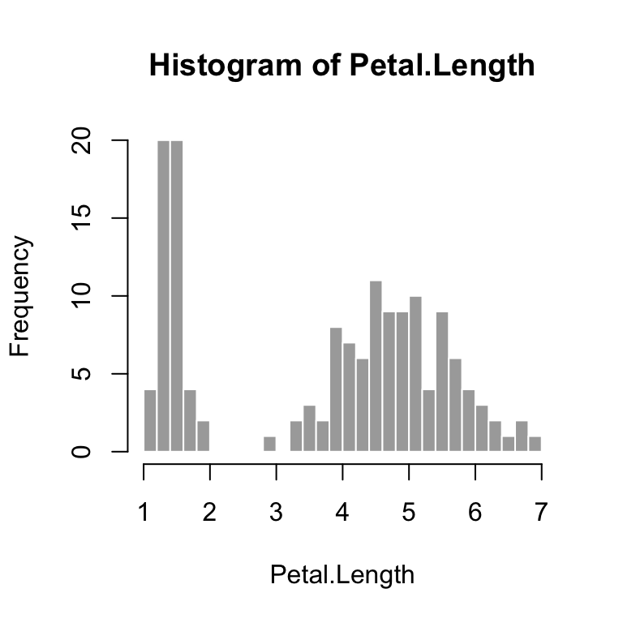

[figure not shown]

# Interested?

Go to the website `https://eva717yifan.shinyapps.io/my_app/` to try out this app.

Or go to the github repo to view the source code `https://github.com/yifan-eva-gong/coursera-ddp-course-project`

Thank you so much for watching the presentation.